# climatic events with the greatest impact

## Introduction

Storms and other severe weather events can cause both public health and economic problems for communities and municipalities. Many severe events can result in fatalities, injuries, and property damage, and preventing such outcomes to the extent possible is a key concern.

This project involves exploring the U.S. National Oceanic and Atmospheric Administration’s (NOAA) storm database. This database tracks characteristics of major storms and weather events in the United States, including when and where they occur, as well as estimates of any fatalities, injuries, and property damage.

## Data Processing

necessary libraries

```r
library(ggplot2)
library(dplyr)
```

first We downlodad dat from [link](https://d396qusza40orc.cloudfront.net/repdata%2Fdata%2FStormData.csv.bz2) and read the data

```r
if (!file.exists("Storm_Data.bz2")){
download.file("https://d396qusza40orc.cloudfront.net/repdata%2Fdata%2FStormData.csv.bz2","Storm_Data.bz2")}

dat<-read.csv(bzfile("Storm_Data.bz2"))
dat$BGN_DATE<-as.Date.character(dat$BGN_DATE,format = c("%m/%d/%Y"))
dat$BGN_DATE<-as.numeric(format(dat$BGN_DATE,"%Y"))
```

after, we save the total fatalities by type of event in the variable called fat and the total injuries in the variable called ing

```r
type<-c("Astronomical Low Tide","Avalanche","Blizzard","Coastal Flood","Cold/Wind Chill","Debris Flow","Dense Fog","Dense Smoke","Drought","Dust Devil","Dust Devil","Excessive Heat","Extreme Cold/Wind Chill","Flash Flood","Flood","Freezing Fog","Frost/Freeze","Funnel Cloud","Hail","Heat","Heavy Rain","Heavy Snow","High Surf","High Wind","Hurricane/Typhoon","Ice Storm","Lakeshore Flood","Lake-Effect Snow","Lightning","Marine Hail","Marine High Wind","Marine Strong Wind","Marine Thunderstorm Wind","Rip Current","Seiche","Sleet","Storm Tide","Strong Wind","Thunderstorm Wind","Tornado","Tropical Depression","Tropical Storm","Tsunami","Volcanic Ash","Waterspout","Wildfire","Winter Storm","Winter Weather")
dat$EVTYPE<-toupper(dat$EVTYPE)
type<-toupper(type)
ind<-dat$EVTYPE %in% type
dat<-dat[ind,]
dat$EVTYPE<-as.factor(dat$EVTYPE)
fat<-dat%>%group_by(EVTYPE)%>%select(EVTYPE,FATALITIES)%>%summarise(total=sum(FATALITIES))%>%arrange(-total)
ing<-dat%>%group_by(EVTYPE)%>%select(EVTYPE,INJURIES)%>%summarise(total=sum(INJURIES))%>%arrange(-total)
```

The ‘CROPDMGEXP’ is the exponent values for ‘CROPDMG’ (crop damage). In the same way, ‘PROPDMGEXP’ is the exponent values for ‘PROPDMG’ (property damage). so to calc the economic impac we need replace the values of ‘PROPDMGEXP’and ’CROPDMGEXP’ with numbers:

- H,h = hundreds = 100
- K,k = kilos = thousands = 1,000
- M,m = millions = 1,000,000
- B,b = billions = 1,000,000,000
- (+) = 1
- (-) = 0
- (?) = 0
- black/empty character = 0
- numeric 0..8 = 10

then, we sum ‘CROPDMG’ and ‘PROPDMG’ to calc the economic impact and we save the total economic impact by type of event in the variable called damage_ec

```r
damage_ec<-select(dat,EVTYPE,PROPDMG,PROPDMGEXP,CROPDMG,CROPDMGEXP)
symbol<-c("","-","?","+","0","1","2","3","4","5","6","7","8","B","b","h","H","k","K","m","M")
equivalence<-c(0,0,0,1,10,10,10,10,10,10,10,10,10,10^9,10^9,10^2,10^2,10^3,10^3,10^6,10^6)
mat_equi<-data.frame(symbol=symbol,equivalence=equivalence)
damage_ec$PROPDMG.equivalence<-mat_equi$equivalence[match(damage_ec$PROPDMGEXP,mat_equi$symbol)]
damage_ec$CROPDMG.equivalence<-mat_equi$equivalence[match(damage_ec$CROPDMGEXP,mat_equi$symbol)]
damage_ec<-damage_ec%>%mutate(PROPDMG=PROPDMG*PROPDMG.equivalence,CROPDMG=CROPDMG*CROPDMG.equivalence)%>%mutate(tot_DMG=PROPDMG+CROPDMG)%>%group_by(EVTYPE)%>%summarise(sum_p=sum(tot_DMG))%>%arrange(-sum_p)
```

## Results

### Health Impact

Tornado is the evente with highest total fatalities

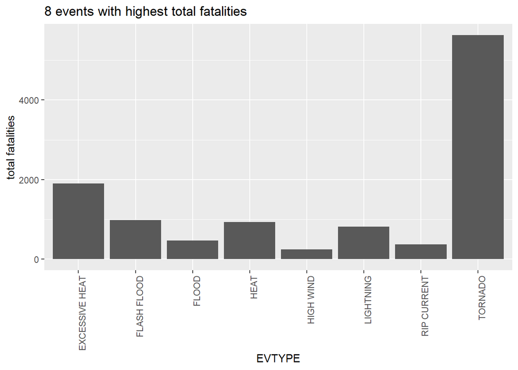

```r
ggplot(fat[1:8,], aes(x=EVTYPE,y=total)) + geom_col()+labs(y="total fatalities",title="8 events with highest total fatalities")+theme(axis.text.x = element_text(angle = 90,hjust = 1))
```

Tornado is the event with highest total injuries

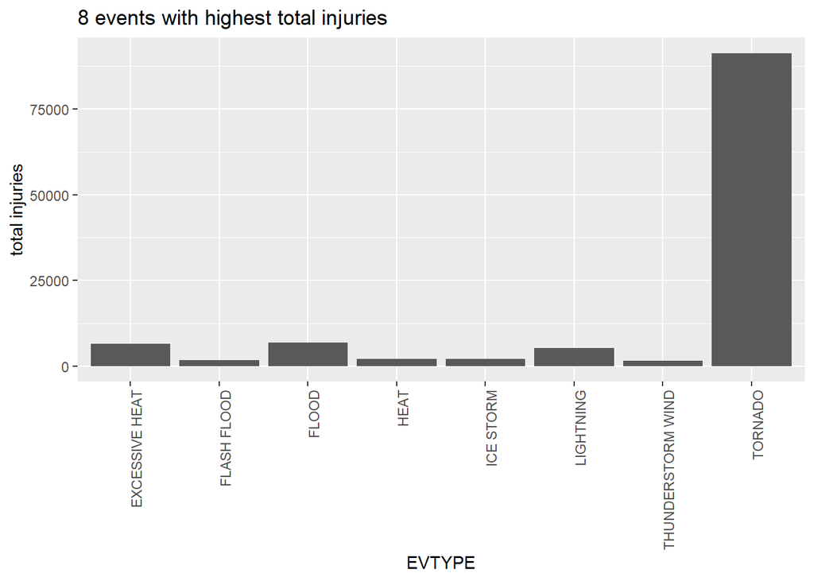

```r
ggplot(ing[1:8,], aes(x=EVTYPE,y=total)) + geom_col()+labs(y="total injuries",title="8 events with highest total injuries")+theme(axis.text.x = element_text(angle = 90,hjust = 1))
```

so Tornado is the event with highest Health Impact

### Economic Impact

Flood es the event with highest total economic impact

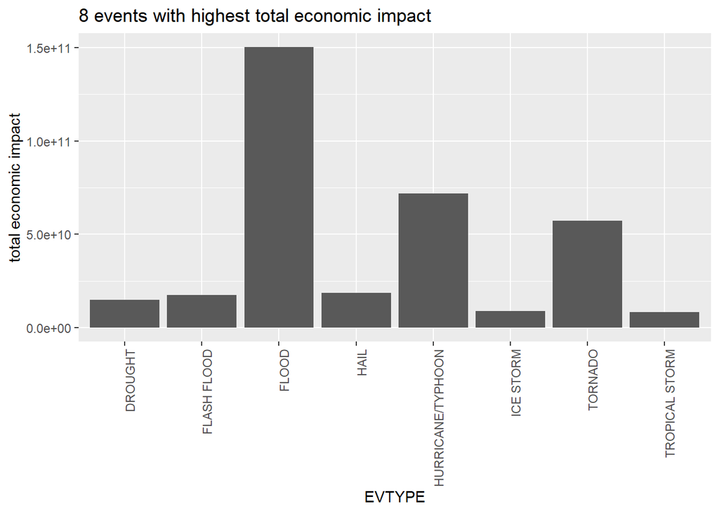

```r
ggplot(damage_ec[1:8,], aes(x=EVTYPE,y=sum_p)) + geom_col()+labs(y="total economic impact",title="8 events with highest total economic impact")+theme(axis.text.x = element_text(angle = 90,hjust = 1))
```